# Machine Learning

## Indah Agustien Siradjuddin

## Naive Bayes Classifier

Semester Gasal 2019-2020

## Naive Bayes

Naive Bayes :

\begin{eqnarray} P(y|x_1,x_2,...,x_j)&=&\frac{P(x_1,x_2,...,x_j|y)p(y)}{P(x_1,x_2,...,x_j)}\\ &=&P(x_1,x_2,...,x_j|y)p(y) \end{eqnarray}

dimana :

- $P(y|x)$ : posterior probability,
- $P(x|y)$ : likelihood atau fitur yang dimiliki dataset
- $P(y)$ : prior probabality
- $P(x_1,x_2,...,x_j)$ : marginal probability (untuk menormalisasi semua hasil posterior probability)

\begin{eqnarray} MAP(P(y|x_1,x_2,...,x_j))&=&max(P(x_1,x_2,...,x_j|y)p(y)) \end{eqnarray}

Naive : $P(x_1,x_2,...,x_j|y)$ adalah independent, sehingga \begin{eqnarray} P(x_1,x_2,...,x_j|y)=P(x_1|y)\times P(x_2|y) \times ... P(x_j|y) \end{eqnarray}

### Categorical Input

Terdapat dataset untuk mengklasifikasikan apakah seorang dosen akan memberikan kuliah ataukah tidak, berdasarkan tiga kondisi yaitu, cuaca, keadaan mobil, dan tugas program studi

[figure not shown]

Hitung likelihood untuk setiap fitur (weather, car, and assignment) \begin{eqnarray} P(weather=sunny|class=teaching)&=&\frac{count(weather=sunny \wedge class=teaching)}{count(class=teaching)}\\ P(weather=rainy|class=teaching)&=&\frac{count(weather=rainy \wedge class=teaching)}{count(class=teaching)}\\ P(car=working|class=teaching)&=&\frac{count(car=working \wedge class=teaching)}{count(class=teaching)}\\ P(car=broken|class=teaching)&=&\frac{count(car=broken \wedge class=teaching)}{count(class=teaching)} \end{eqnarray}

likelihood untuk setiap fitur

[figure not shown]

Posterior Probability dari Data

[figure not shown]

## Gaussian Naive Bayes

\begin{eqnarray} P(x|y)=\frac{1}{\sqrt{2\pi \sigma_y^2}}e^{\frac{(x-\mu_y)^2}{\sigma_y^2}} \end{eqnarray}

dimana  
$\mu_y$ and $\sigma_y$ adalah *mean* dan *variance* untuk setiap fitur $x$ pada setiap class $y$

```python
from sklearn import datasets
import numpy as np
import matplotlib.pyplot as plt
iris=datasets.load_iris()
dataTrain1=iris.data[1:5,:]
dataTrain2=iris.data[51:55,:]
dataTrain3=iris.data[101:105,:]
dataTrain=np.concatenate((dataTrain1, dataTrain2,dataTrain3), axis=0)
targetTrain1=iris.target[1:5]
targetTrain2=iris.target[51:55]
targetTrain3=iris.target[101:105]
targetTrain=np.concatenate((targetTrain1,targetTrain2,targetTrain3),axis=0)
print(dataTrain)
print(targetTrain)
```

```
[[4.9 3.  1.4 0.2]
 [4.7 3.2 1.3 0.2]
 [4.6 3.1 1.5 0.2]
 [5.  3.6 1.4 0.2]
 [6.4 3.2 4.5 1.5]
 [6.9 3.1 4.9 1.5]
 [5.5 2.3 4.  1.3]
 [6.5 2.8 4.6 1.5]
 [5.8 2.7 5.1 1.9]
 [7.1 3.  5.9 2.1]
 [6.3 2.9 5.6 1.8]
 [6.5 3.  5.8 2.2]]
[0 0 0 0 1 1 1 1 2 2 2 2]
```

### Naive Bayes dengan Scikit

```python
from sklearn.naive_bayes import GaussianNB

nbc=GaussianNB()
model=nbc.fit(dataTrain,targetTrain)
```

```python
print('mean=',model.theta_)
print('variance=',model.sigma_)
```

```
mean= [[4.8   3.225 1.4   0.2  ]
 [6.325 2.85  4.5   1.45 ]
 [6.425 2.9   5.6   2.   ]]
variance= [[2.50000032e-02 5.18750032e-02 5.00000323e-03 3.23055556e-09]
 [2.61875003e-01 1.22500003e-01 1.05000003e-01 7.50000323e-03]
 [2.16875003e-01 1.50000032e-02 9.50000032e-02 2.50000032e-02]]
```

```python
model.predict(dataTrain)
```

```
array([0, 0, 0, 0, 1, 1, 1, 1, 2, 2, 2, 2])
```

### Code Naive Bayes

```python
def trainNBC(featureData,numOfClass):
    #print(featureData.shape[1])
    numOfFeature=featureData.shape[1]
    numOfEachClass=featureData.shape[0]//numOfClass
    #print(numOfEachClass)
    meanFeat=[]
    devFeat=[]
    for c in range(numOfClass):
        tempMean=[]
        tempDev=[]
        for i in range(numOfFeature):
            temp=np.mean(featureData[c*numOfEachClass:(c+1)*numOfEachClass,i])
            temp2=np.var(featureData[c*numOfEachClass:(c+1)*numOfEachClass,i])
            tempMean.append(temp)
            tempDev.append(temp2)
        meanFeat.append(tempMean)
        devFeat.append(tempDev)
    return(meanFeat,devFeat)

def pdfX(x,meanX,stdX):
    if stdX==0:
        stdX=0.1
    temp=1/(2*np.pi*stdX**2)
    #print('stdA=',x,meanX,stdX)
    temp2=np.exp(-1*(x-meanX)**2/(stdX**2))
    return(temp*temp2)

def showPDF(meanX,stdX):
    x=np.linspace(-4,15,30)
    y=pdfX(x,meanX,stdX)
    %matplotlib inline
    plt.plot(x,y,'r-')

def MAP(x,meanData,stdData,numOfClass,numOfFeature):
    prior=0.25
    posterior=[]
    for i in range(numOfClass):
        temp=1
        for j in range(numOfFeature):
            temp=temp*pdfX(x[j],meanData[i][j],stdData[i][j])
            #print(str(i),',',str(j),'=',temp)
        temp=temp*prior
        posterior.append(temp)
    #print('posterior=',posterior,np.argmax(posterior))
    kelas=np.argmax(posterior)
    return kelas
```

```
mean= [[4.800000000000001, 3.225, 1.4, 0.2], [6.325, 2.8500000000000005, 4.5, 1.45], [6.425, 2.9, 5.6000000000000005, 2.0]]
std= [[0.025000000000000043, 0.051875000000000004, 0.0049999999999999975, 0.0], [0.26187500000000014, 0.12250000000000008, 0.10500000000000005, 0.007499999999999997], [0.21687499999999993, 0.014999999999999982, 0.09500000000000013, 0.025000000000000022]]
```

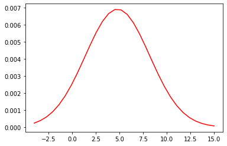

```python
meanAll,stdAll=trainNBC(dataTrain,3)
print('mean=',meanAll)
print('std=',stdAll)
showPDF(meanAll[0][0],meanAll[0][0])
```

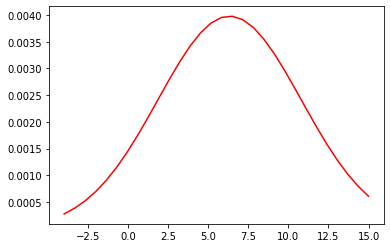

```python
showPDF(meanAll[1][0],meanAll[1][0])
```

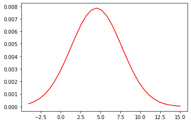

```python
showPDF(meanAll[1][2],meanAll[1][2])
```

```python
for i in dataTrain:
    kelas=MAP(i,meanAll,stdAll,3,4)
    print('kelas=',kelas)
```

```
kelas= 0
kelas= 0
kelas= 0
kelas= 0
kelas= 1
kelas= 1
kelas= 1
kelas= 1
kelas= 2
kelas= 2
kelas= 2
kelas= 2
```